# Freelance Singapore

Shyni

1/27/2020

I have a dataset containing all the property transactions from Jan 2016 to Jan 2019. Need to generate 2 insights and 1 predictive model using the dataset The model must be either a Linear Regression Logistic Regression Machine Learning using Linear/Logistic Regression K-means clustering model KNN classification model

Load libraries

```r
library(tidyverse)
```

```r
library(readr)
library(dplyr)
library(ggplot2)
library(sqldf)
#install.packages("readxl")
library(readxl)
library(scales)
library(stringr)
#install.packages("caret")
library(caret)
 library(glmnet)
library(gridExtra)
#install.packages("VIM")
library(VIM)
#install.packages("car")
library(car)
library(caretEnsemble) # for Stacking
#install.packages("doParallel")
library(doParallel)  # parallel processing
#install.packages("nnet")
library(nnet) # for multinomial logit

load("~/Desktop/New Jobs/Freelance Singapore/Singapore_Property_DS.RData")
```

Import Data

```r
setwd("~/Desktop/New Jobs/Freelance Singapore")
URA <- read.csv("URAdata.csv")
```

Data Wrangling

```r
URA_01 <- URA
colnames(URA_01) <- c("Project_Name", "Strret_Name", "Type", "Postal_District", "Market_Segment", "Tenure", "Type_of_Sale", "No_of_Units", "Price", "Net_Price", "Area_Sqft", "Type_of_Area", "Floor_Level", "Unit_Price", "Date_of_Sale", "SIBOR_rate", "Leading_Indicator", "Year", "Year.1", "Real_GDP")

glimpse(URA_01)
```

```
## Observations: 56,283
## Variables: 20
## $ Project_Name      <fct> TAMPINES COURT, PARK WEST, SHUNFU VILLE, FLORE…
## $ Strret_Name       <fct> TAMPINES STREET 11, JALAN LEMPENG, SHUNFU ROAD…
## $ Type              <fct> Condominium, Condominium, Apartment, Apartment…
## $ Postal_District   <int> 18, 5, 20, 19, 14, 9, 3, 19, 19, 15, 13, 10, 1…
## $ Market_Segment    <fct> OCR, OCR, RCR, OCR, RCR, CCR, RCR, OCR, OCR, R…
## $ Tenure            <fct> 101 yrs lease commencing from 1985, 99 yrs lea…
## $ Type_of_Sale      <fct> Resale, Resale, Resale, Resale, Resale, Resale…
## $ No_of_Units       <int> 560, 436, 358, 336, 330, 290, 288, 286, 244, 2…
## $ Price             <int> 970000000, 840888888, 638000000, 629000000, 76…
## $ Net_Price         <fct> -, -, -, -, -, -, -, -, -, -, -, -, -, -, -, -…
## $ Area_Sqft         <int> 947081, 629263, 601040, 563829, 558565, 416750…
## $ Type_of_Area      <fct> Strata, Strata, Strata, Strata, Strata, Strata…
## $ Floor_Level       <fct> 01 to 05, 01 to 05, 01 to 05, 06 to 10, 01 to …
## $ Unit_Price        <int> 1024, 1336, 1061, 1116, 1371, 2352, 1399, 1199…
## $ Date_of_Sale      <fct> Aug-17, Jan-18, May-16, Oct-17, May-17, Mar-18…
## $ SIBOR_rate        <dbl> 1.119, 1.504, 1.005, 1.123, 0.998, 1.373, 1.12…
## $ Leading_Indicator <dbl> 105.6, 105.7, 107.5, 109.8, 109.5, 109.4, 109.…
## $ Year              <fct> 2017 1Q, 2017 2Q, 2017 3Q, 2017 4Q, 2018 1Q, 2…
## $ Year.1            <int> 2016, 2017, 2018, 2019, NA, NA, NA, NA, NA, NA…
## $ Real_GDP          <dbl> 3.0, 3.7, 3.1, NA, NA, NA, NA, NA, NA, NA, NA,…
```

```r
URA_02 <- URA_01

#Make Net price from factor to numeric
URA_02$Net_Price   <-  as.character(URA_02$Net_Price)
URA_02$Net_Price   <-  as.numeric(URA_02$Net_Price)
glimpse(URA_02)
```

```
## Observations: 56,283
## Variables: 20
## $ Project_Name      <fct> TAMPINES COURT, PARK WEST, SHUNFU VILLE, FLORE…
## $ Strret_Name       <fct> TAMPINES STREET 11, JALAN LEMPENG, SHUNFU ROAD…
## $ Type              <fct> Condominium, Condominium, Apartment, Apartment…
## $ Postal_District   <int> 18, 5, 20, 19, 14, 9, 3, 19, 19, 15, 13, 10, 1…
## $ Market_Segment    <fct> OCR, OCR, RCR, OCR, RCR, CCR, RCR, OCR, OCR, R…
## $ Tenure            <fct> 101 yrs lease commencing from 1985, 99 yrs lea…
## $ Type_of_Sale      <fct> Resale, Resale, Resale, Resale, Resale, Resale…
## $ No_of_Units       <int> 560, 436, 358, 336, 330, 290, 288, 286, 244, 2…
## $ Price             <int> 970000000, 840888888, 638000000, 629000000, 76…
## $ Net_Price         <dbl> NA, NA, NA, NA, NA, NA, NA, NA, NA, NA, NA, NA…
## $ Area_Sqft         <int> 947081, 629263, 601040, 563829, 558565, 416750…
## $ Type_of_Area      <fct> Strata, Strata, Strata, Strata, Strata, Strata…
## $ Floor_Level       <fct> 01 to 05, 01 to 05, 01 to 05, 06 to 10, 01 to …
## $ Unit_Price        <int> 1024, 1336, 1061, 1116, 1371, 2352, 1399, 1199…
## $ Date_of_Sale      <fct> Aug-17, Jan-18, May-16, Oct-17, May-17, Mar-18…
## $ SIBOR_rate        <dbl> 1.119, 1.504, 1.005, 1.123, 0.998, 1.373, 1.12…
## $ Leading_Indicator <dbl> 105.6, 105.7, 107.5, 109.8, 109.5, 109.4, 109.…
## $ Year              <fct> 2017 1Q, 2017 2Q, 2017 3Q, 2017 4Q, 2018 1Q, 2…
## $ Year.1            <int> 2016, 2017, 2018, 2019, NA, NA, NA, NA, NA, NA…
## $ Real_GDP          <dbl> 3.0, 3.7, 3.1, NA, NA, NA, NA, NA, NA, NA, NA,…
```

```r
#Split Date of Sale to Month and day
URA_03 <- URA_02
URA_03_01 <- URA_03 %>% separate(Date_of_Sale, c("Sale_Month", "Sale_Day"), sep="-")
glimpse(URA_03_01)
```

```
## Observations: 56,283
## Variables: 21
## $ Project_Name      <fct> TAMPINES COURT, PARK WEST, SHUNFU VILLE, FLORE…
## $ Strret_Name       <fct> TAMPINES STREET 11, JALAN LEMPENG, SHUNFU ROAD…
## $ Type              <fct> Condominium, Condominium, Apartment, Apartment…
## $ Postal_District   <int> 18, 5, 20, 19, 14, 9, 3, 19, 19, 15, 13, 10, 1…
## $ Market_Segment    <fct> OCR, OCR, RCR, OCR, RCR, CCR, RCR, OCR, OCR, R…
## $ Tenure            <fct> 101 yrs lease commencing from 1985, 99 yrs lea…
## $ Type_of_Sale      <fct> Resale, Resale, Resale, Resale, Resale, Resale…
## $ No_of_Units       <int> 560, 436, 358, 336, 330, 290, 288, 286, 244, 2…
## $ Price             <int> 970000000, 840888888, 638000000, 629000000, 76…
## $ Net_Price         <dbl> NA, NA, NA, NA, NA, NA, NA, NA, NA, NA, NA, NA…
## $ Area_Sqft         <int> 947081, 629263, 601040, 563829, 558565, 416750…
## $ Type_of_Area      <fct> Strata, Strata, Strata, Strata, Strata, Strata…
## $ Floor_Level       <fct> 01 to 05, 01 to 05, 01 to 05, 06 to 10, 01 to …
## $ Unit_Price        <int> 1024, 1336, 1061, 1116, 1371, 2352, 1399, 1199…
## $ Sale_Month        <chr> "Aug", "Jan", "May", "Oct", "May", "Mar", "Feb…
## $ Sale_Day          <chr> "17", "18", "16", "17", "17", "18", "18", "17"…
## $ SIBOR_rate        <dbl> 1.119, 1.504, 1.005, 1.123, 0.998, 1.373, 1.12…
## $ Leading_Indicator <dbl> 105.6, 105.7, 107.5, 109.8, 109.5, 109.4, 109.…
## $ Year              <fct> 2017 1Q, 2017 2Q, 2017 3Q, 2017 4Q, 2018 1Q, 2…
## $ Year.1            <int> 2016, 2017, 2018, 2019, NA, NA, NA, NA, NA, NA…
## $ Real_GDP          <dbl> 3.0, 3.7, 3.1, NA, NA, NA, NA, NA, NA, NA, NA,…
```

```r
#Split Year and Qtr
URA_03_02 <- URA_03_01 %>% separate(Year, c("Year", "Quarter"), sep=" ")
glimpse(URA_03_02)
```

```
## Observations: 56,283
## Variables: 22
## $ Project_Name      <fct> TAMPINES COURT, PARK WEST, SHUNFU VILLE, FLORE…
## $ Strret_Name       <fct> TAMPINES STREET 11, JALAN LEMPENG, SHUNFU ROAD…
## $ Type              <fct> Condominium, Condominium, Apartment, Apartment…
## $ Postal_District   <int> 18, 5, 20, 19, 14, 9, 3, 19, 19, 15, 13, 10, 1…
## $ Market_Segment    <fct> OCR, OCR, RCR, OCR, RCR, CCR, RCR, OCR, OCR, R…
## $ Tenure            <fct> 101 yrs lease commencing from 1985, 99 yrs lea…
## $ Type_of_Sale      <fct> Resale, Resale, Resale, Resale, Resale, Resale…
## $ No_of_Units       <int> 560, 436, 358, 336, 330, 290, 288, 286, 244, 2…
## $ Price             <int> 970000000, 840888888, 638000000, 629000000, 76…
## $ Net_Price         <dbl> NA, NA, NA, NA, NA, NA, NA, NA, NA, NA, NA, NA…
## $ Area_Sqft         <int> 947081, 629263, 601040, 563829, 558565, 416750…
## $ Type_of_Area      <fct> Strata, Strata, Strata, Strata, Strata, Strata…
## $ Floor_Level       <fct> 01 to 05, 01 to 05, 01 to 05, 06 to 10, 01 to …
## $ Unit_Price        <int> 1024, 1336, 1061, 1116, 1371, 2352, 1399, 1199…
## $ Sale_Month        <chr> "Aug", "Jan", "May", "Oct", "May", "Mar", "Feb…
## $ Sale_Day          <chr> "17", "18", "16", "17", "17", "18", "18", "17"…
## $ SIBOR_rate        <dbl> 1.119, 1.504, 1.005, 1.123, 0.998, 1.373, 1.12…
## $ Leading_Indicator <dbl> 105.6, 105.7, 107.5, 109.8, 109.5, 109.4, 109.…
## $ Year              <chr> "2017", "2017", "2017", "2017", "2018", "2018"…
## $ Quarter           <chr> "1Q", "2Q", "3Q", "4Q", "1Q", "2Q", "3Q", "4Q"…
## $ Year.1            <int> 2016, 2017, 2018, 2019, NA, NA, NA, NA, NA, NA…
## $ Real_GDP          <dbl> 3.0, 3.7, 3.1, NA, NA, NA, NA, NA, NA, NA, NA,…
```

```r
URA_03_02$Year <- as.numeric(URA_03_02$Year)

#to check for NA's
summary(URA_03_02)
```

```
##                    Project_Name                    Strret_Name
##  RIVERFRONT RESIDENCES   :  840   TAMPINES STREET 86     : 1637
##  KINGSFORD WATERBAY      :  832   WEST COAST VALE        : 1444
##  PARC RIVIERA            :  753   UPPER SERANGOON VIEW   :  977
##  SEASIDE RESIDENCES      :  729   HOUGANG AVENUE 7       :  898
##  LAKE GRANDE             :  711   JURONG LAKE LINK       :  852
##  GRANDEUR PARK RESIDENCES:  699   PRINCE CHARLES CRESCENT:  829
##  (Other)                 :51719   (Other)                :49646
##           Type       Postal_District Market_Segment
##             :    2   Min.   : 1.00      :    2
##  Apartment  :20541   1st Qu.: 9.00   CCR: 9462
##  Condominium:35740   Median :15.00   OCR:27873
##                      Mean   :14.21   RCR:18946
##                      3rd Qu.:19.00
##                      Max.   :28.00
##                      NA's   :2
##                                Tenure        Type_of_Sale
##  Freehold                         :16046           :    2
##  99 yrs lease commencing from 2015: 5146   New Sale:25528
##  99 yrs lease commencing from 2016: 3947   Resale  :29602
##  99 yrs lease commencing from 2014: 3572   Sub Sale: 1151
##  99 yrs lease commencing from 2013: 3237
##  (Other)                          :24333
##  NA's                             :    2
##   No_of_Units           Price             Net_Price
##  Min.   :    1.00   Min.   :   288000   Min.   :  647000
##  1st Qu.:    1.00   1st Qu.:   930000   1st Qu.:  952586
##  Median :    1.00   Median :  1230000   Median : 1261000
##  Mean   :    2.21   Mean   :  1794089   Mean   : 1320503
##  3rd Qu.:    1.00   3rd Qu.:  1650000   3rd Qu.: 1414500
##  Max.   :62259.00   Max.   :980000000   Max.   :12063567
##  NA's   :1          NA's   :2           NA's   :55816
##    Area_Sqft      Type_of_Area     Floor_Level      Unit_Price
##  Min.   :   258         :    2   01 to 05:20238   Min.   : 237
##  1st Qu.:   689   Land  :   15   06 to 10:14099   1st Qu.:1084
##  Median :   980   Strata:56266   11 to 15:10229   Median :1354
##  Mean   :  1250                  16 to 20: 5055   Mean   :1418
##  3rd Qu.:  1281                  21 to 25: 2579   3rd Qu.:1651
##  Max.   :947081                  26 to 30: 1749   Max.   :4630
##  NA's   :2                       (Other) : 2334   NA's   :2
##   Sale_Month          Sale_Day           SIBOR_rate    Leading_Indicator
##  Length:56283       Length:56283       Min.   :0.871   Min.   :105.6
##  Class :character   Class :character   1st Qu.:0.961   1st Qu.:107.6
##  Mode  :character   Mode  :character   Median :1.123   Median :109.0
##                                        Mean   :1.194   Mean   :108.3
##                                        3rd Qu.:1.507   3rd Qu.:109.2
##                                        Max.   :1.886   Max.   :109.8
##                                        NA's   :2       NA's   :56272
##       Year         Quarter              Year.1         Real_GDP
##  Min.   :2017    Length:56283       Min.   :2016    Min.   :3.00
##  1st Qu.:2017    Class :character   1st Qu.:2017    1st Qu.:3.05
##  Median :2018    Mode  :character   Median :2018    Median :3.10
##  Mean   :2018                       Mean   :2018    Mean   :3.27
##  3rd Qu.:2018                       3rd Qu.:2018    3rd Qu.:3.40
##  Max.   :2019                       Max.   :2019    Max.   :3.70
##  NA's   :56272                      NA's   :56279   NA's   :56280
```

```r
#removing outlier
URA_03_03 <- URA_03_02 %>%   filter(!is.na(Price))
URA_03_03_01 <- URA_03_03 %>%   filter(!is.na(Tenure))
#log value
URA_03_04 <- URA_03_03 %>% mutate(logPrice = log(Price))
URA_03_05 <- URA_03_04 %>% mutate(logASqft = log(Area_Sqft))
URA_03_06 <- URA_03_05 %>% mutate(logNUnits = log(No_of_Units))

#mean
meanPrice <- mean(URA_03_06$logPrice)
```

Univariate analysis

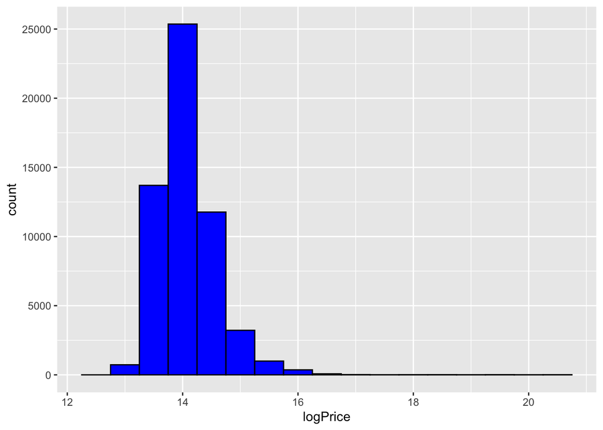

```r
ggplot(URA_03_06) + geom_histogram(aes(logPrice), binwidth = .5, fill = "blue",col = "black")
```

The Price range between $730000 to $1983000 is the most frequent rate for housing metrics i.e. approximately 88%.

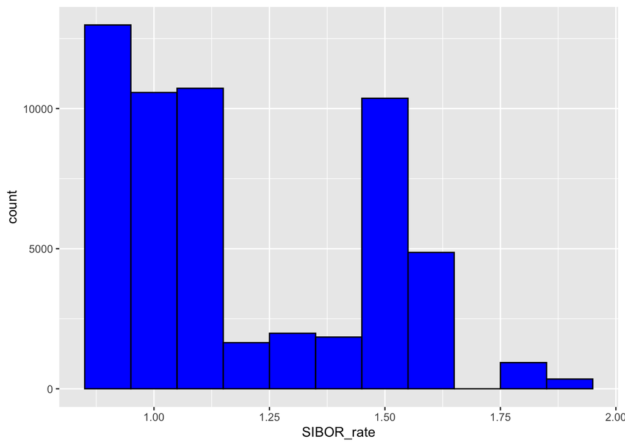

```r
ggplot(URA_03_03) + geom_histogram(aes(SIBOR_rate), binwidth = .1, fill = "blue",col = "black")
```

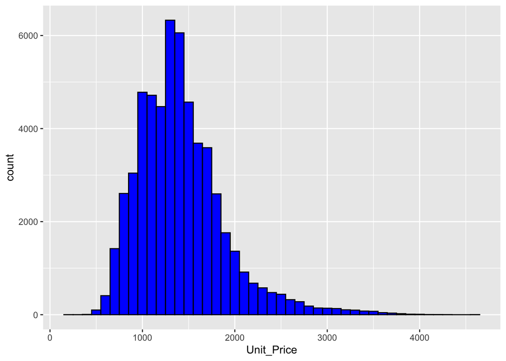

```r
ggplot(URA_03_03) + geom_histogram(aes(Unit_Price), binwidth =100, fill = "blue",col = "black")
```

The most popular Unit Price preferred for purchase ranges between $1000 to $2000.

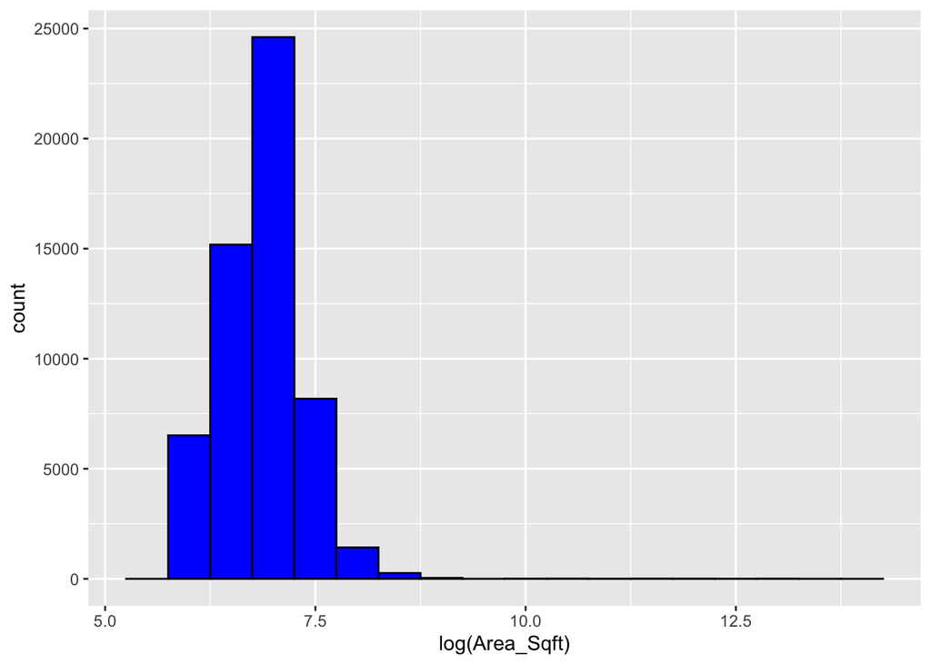

```r
ggplot(URA_03_03) + geom_histogram(aes(log(Area_Sqft)), binwidth =.5, fill = "blue",col = "black")
```

The most in demand Sqft sold are in the range of 409 sqft to 1098 sqft.

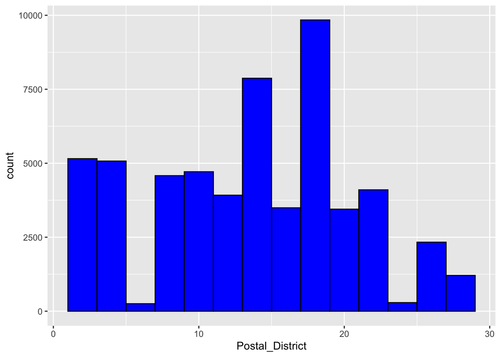

```r
ggplot(URA_03_03) + geom_histogram(aes(Postal_District), binwidth =2, fill = "blue",col = "black")
```

The maximum houses sold are in postal district 17 and 19.

[figure not shown]

```r
ggplot(URA_03_03) + geom_histogram(aes(log(No_of_Units)), binwidth = 50, fill = "blue",col = "black")
```

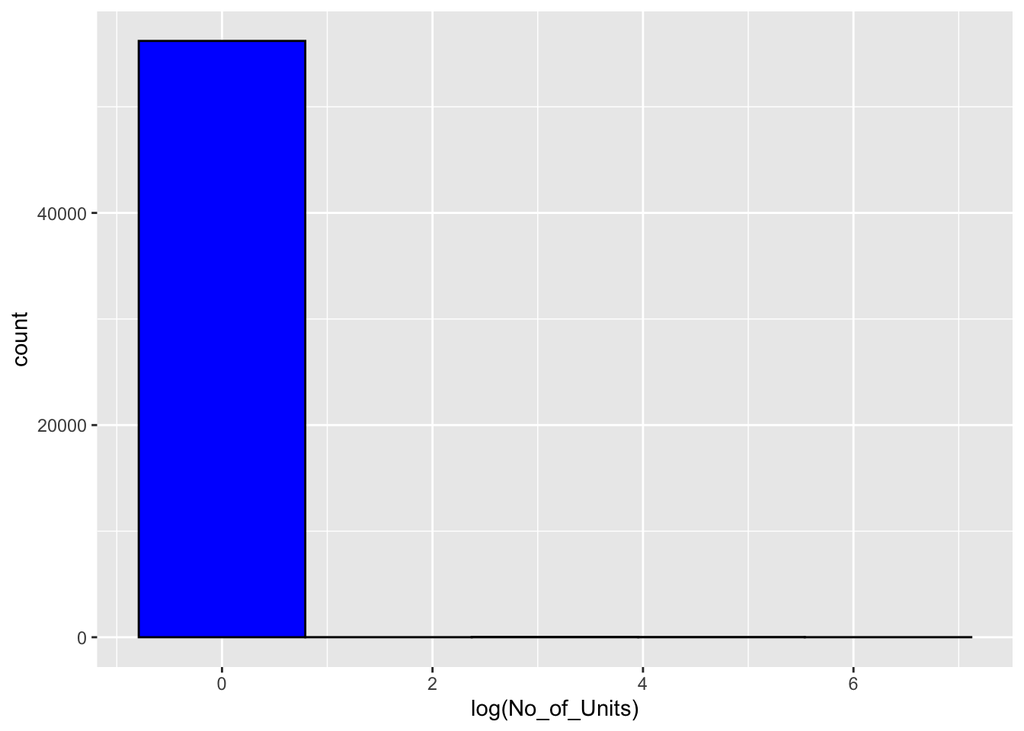

```r
ggplot(URA_03_03, aes(log(No_of_Units))) +
  geom_histogram(bins = 5, fill = "blue", col="black")
```

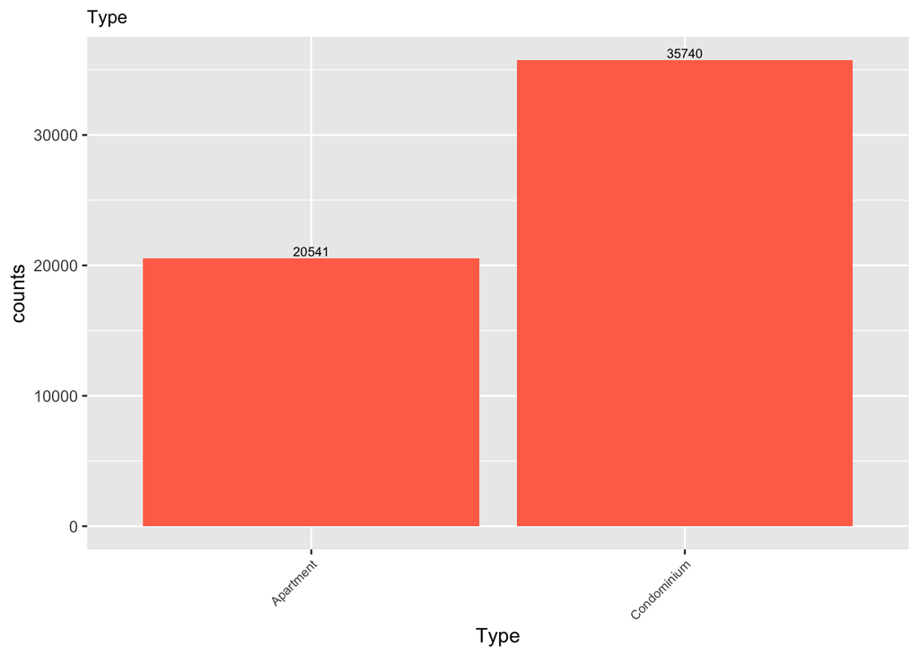

```r
URA_03_03 %>%
  group_by(Type) %>%
  summarise(counts = n()) %>%
  ggplot(aes(x = Type, y = counts)) + geom_bar(stat = 'identity', fill = "coral1") + ggtitle("Type") +geom_text(aes(label=counts), size = 2.5, position=position_dodge(width=0.2), vjust=-0.25) + theme(plot.title = element_text(size =10),axis.text.x = element_text(size =7,angle = 45, hjust = 1))
```

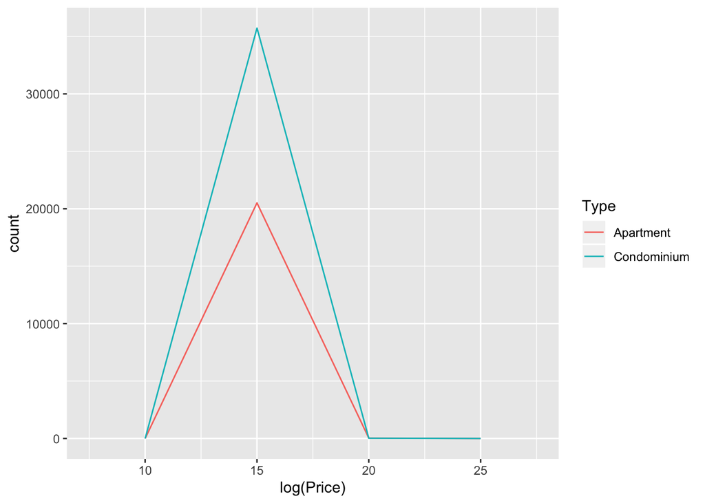

```r
#Type vs Price
ggplot(URA_03_03, aes(log(Price), colour = Type)) +
  geom_freqpoly(binwidth = 5)
```

63.5% of houses sold are Condiminium making it more sort after compared to 36.5% of property sold as Apartments.

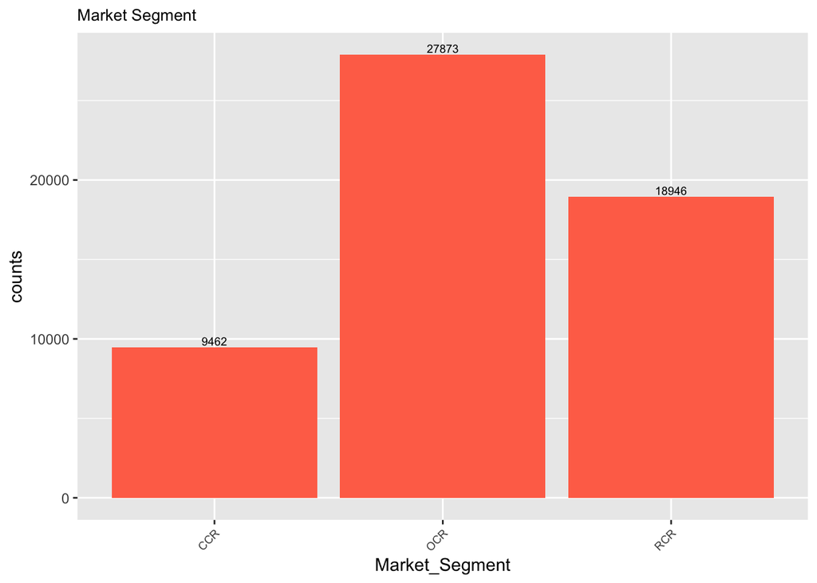

```r
URA_03_03 %>%
  group_by(Market_Segment) %>%
  summarise(counts = n()) %>%
  ggplot(aes(x = Market_Segment, y = counts)) + geom_bar(stat = 'identity', fill = "coral1") + ggtitle("Market Segment") +geom_text(aes(label=counts), size = 2.5, position=position_dodge(width=0.2), vjust=-0.25) + theme(plot.title = element_text(size =10),axis.text.x = element_text(size =7,angle = 45, hjust = 1))
```

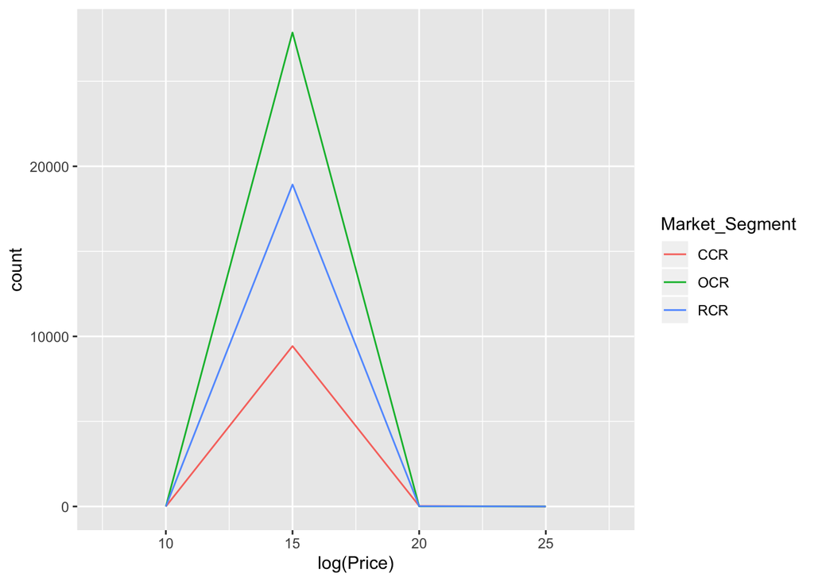

```r
#Market Segment vs Price
ggplot(URA_03_03, aes(log(Price), colour = Market_Segment)) +
  geom_freqpoly(binwidth = 5)
```

Approximately 49.5% of the Market Segment belongs to OCR.

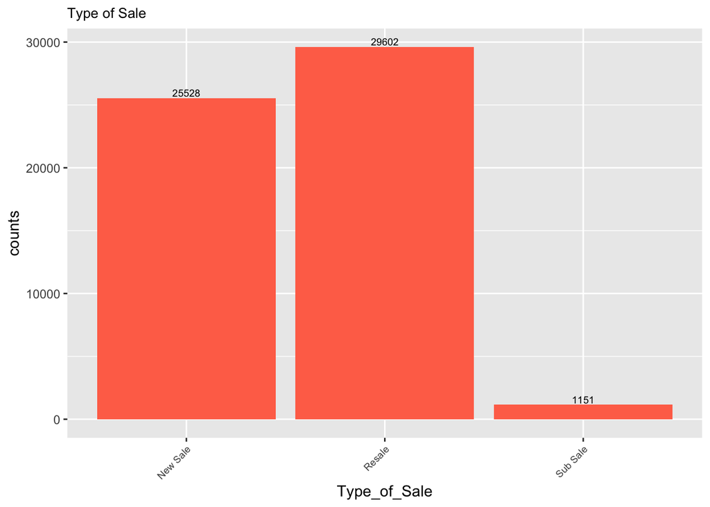

```r
URA_03_03 %>%
  group_by(Type_of_Sale) %>%
  summarise(counts = n()) %>%
  ggplot(aes(x = Type_of_Sale, y = counts)) + geom_bar(stat = 'identity', fill = "coral1") + ggtitle("Type of Sale") +geom_text(aes(label=counts), size = 2.5, position=position_dodge(width=0.2), vjust=-0.25) + theme(plot.title = element_text(size =10),axis.text.x = element_text(size =7,angle = 45, hjust = 1))
```

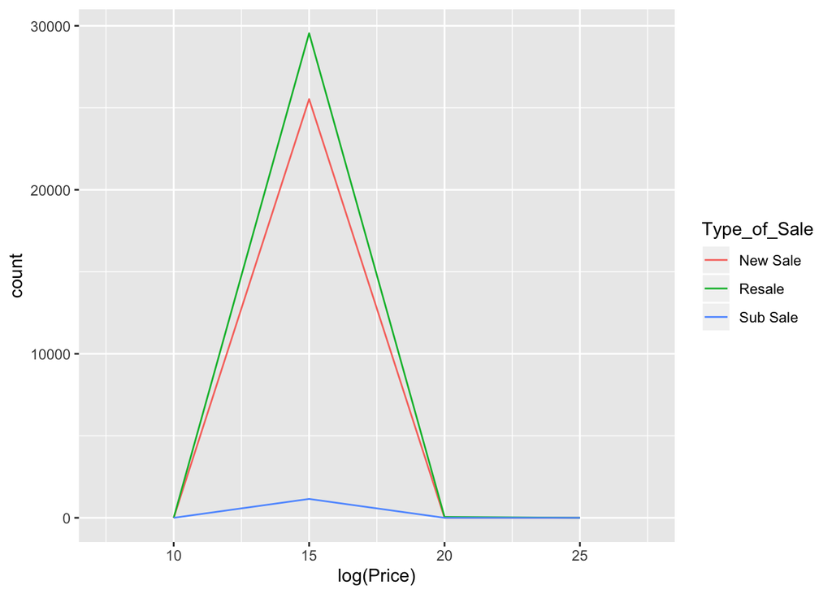

```r
#Type of Sale vs Price
ggplot(URA_03_03, aes(log(Price), colour = Type_of_Sale)) +
  geom_freqpoly(binwidth = 5)
```

The most prominent Type of Sale s Resale followed by New Sale. Sub Sale is very rare.

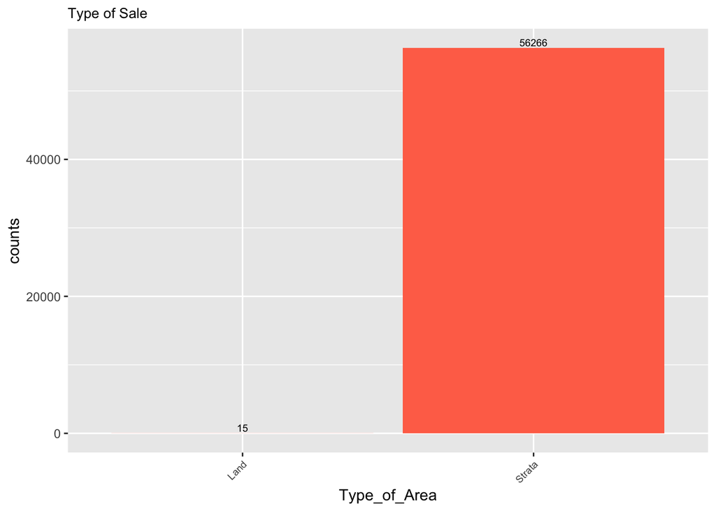

```r
URA_03_03 %>%
  group_by(Type_of_Area) %>%
  summarise(counts = n()) %>%
  ggplot(aes(x = Type_of_Area, y = counts)) + geom_bar(stat = 'identity', fill = "coral1") + ggtitle("Type of Sale") +geom_text(aes(label=counts), size = 2.5, position=position_dodge(width=0.2), vjust=-0.25) + theme(plot.title = element_text(size =10),axis.text.x = element_text(size =7,angle = 45, hjust = 1))
```

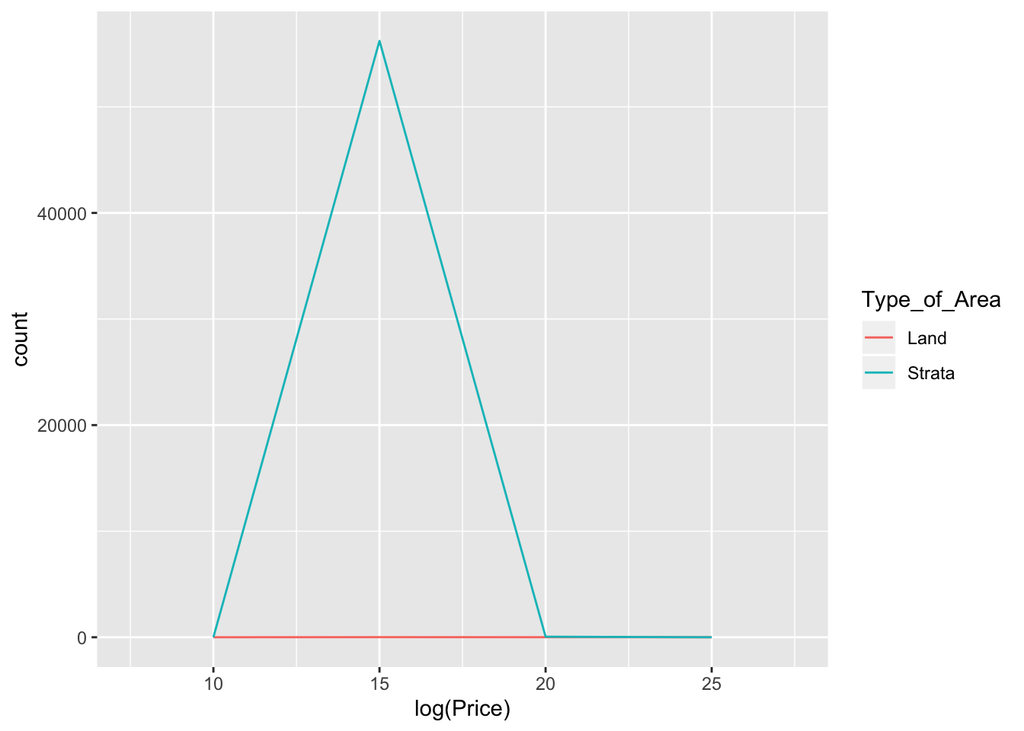

```r
#Type of Area vs Price
ggplot(URA_03_03, aes(log(Price), colour = Type_of_Area)) +
  geom_freqpoly(binwidth = 5)
```

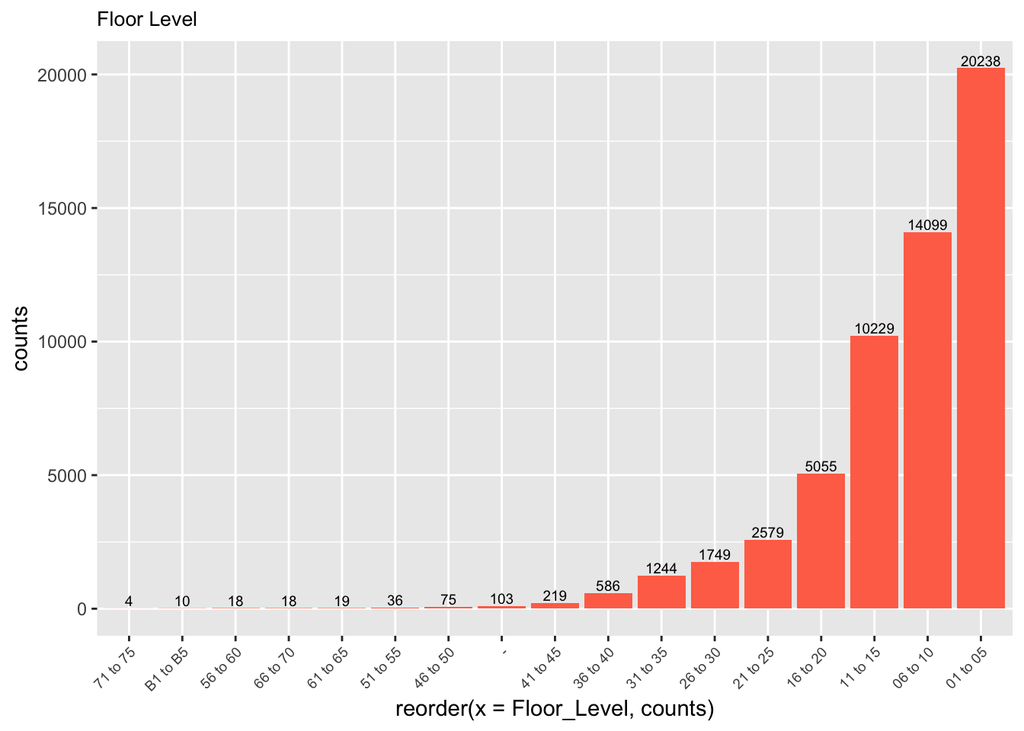

```r
URA_03_03 %>%
  group_by(Floor_Level) %>%
  summarise(counts = n()) %>%
  ggplot(aes(reorder(x = Floor_Level,counts), y = counts)) + geom_bar(stat = 'identity', fill = "coral1") + ggtitle("Floor Level") +geom_text(aes(label=counts), size = 2.5, position=position_dodge(width=0.2), vjust=-0.25) + theme(plot.title = element_text(size =10),axis.text.x = element_text(size =7,angle = 45, hjust = 1))
```

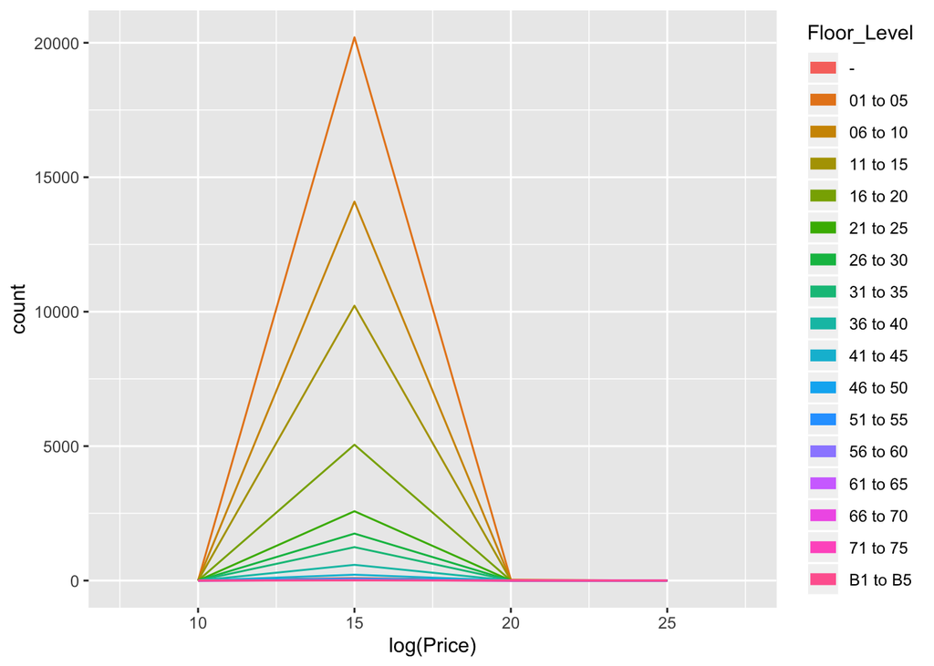

```r
#Type of Area vs Price
ggplot(URA_03_03, aes(log(Price), colour = Floor_Level)) +
  geom_freqpoly(binwidth = 5) +  scale_fill_manual(values=c("red", "darkgreen", "springgreen1", "turquoise2", "yellow", "grey", "purple", "salmon2", "olivedrab3", "magenta2", "khaki3", "brown2", "maroon2", "coral1", "grey45", "goldenrod1", "slategray3","tan4", "orchid3", "hotpink4", "black", "brown4", "lightpink2" )) + guides(colour = guide_legend(override.aes = list(size=3, alpha = 1))) + scale_shape_manual(values=c(3:9))
```

The most popular Floor Level sold ranges from 01 to 05 followed by 06 to 10 and 11 to 15.

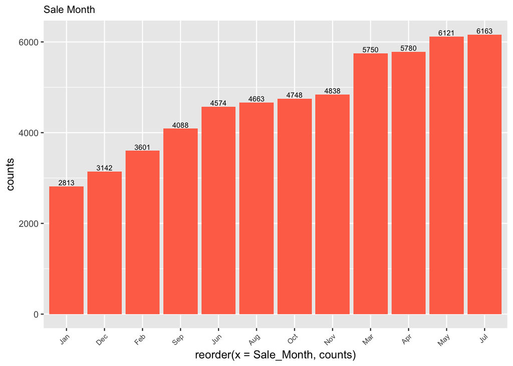

```r
URA_03_03 %>%
  group_by(Sale_Month) %>%
  summarise(counts = n()) %>%
  ggplot(aes(reorder(x = Sale_Month, counts), y = counts)) + geom_bar(stat = 'identity', fill = "coral1") + ggtitle("Sale Month") +geom_text(aes(label=counts), size = 2.5, position=position_dodge(width=0.2), vjust=-0.25) + theme(plot.title = element_text(size =10),axis.text.x = element_text(size =7,angle = 45, hjust = 1))
```

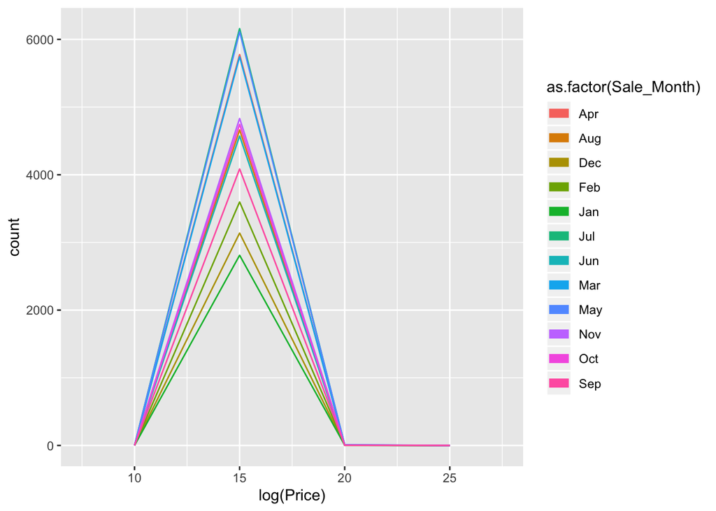

```r
#Sale_Month vs Price
ggplot(URA_03_03, aes(log(Price), colour = as.factor(Sale_Month))) +
  geom_freqpoly(binwidth = 5) +  scale_fill_manual(values=c("red", "darkgreen", "springgreen1", "turquoise2", "yellow", "grey", "purple", "salmon2", "olivedrab3", "magenta2", "khaki3", "brown2", "maroon2", "coral1", "grey45", "goldenrod1", "slategray3","tan4", "orchid3", "hotpink4", "black", "brown4", "lightpink2" )) + guides(colour = guide_legend(override.aes = list(size=3, alpha = 1))) + scale_shape_manual(values=c(3:9))
```

March, April, May and July are the highest sale months. The next set of popular sale months are June, August, September,October and November.

Linear Regression Models

```r
model_11x <-  lm(Price ~  Project_Name +Strret_Name+ Type+ Postal_District+Market_Segment+ Tenure+Type_of_Sale+No_of_Units+Area_Sqft+ Type_of_Area+Floor_Level+ Unit_Price+ Sale_Month, data = URA_03_03)


j<- data.frame(summary(model_11x)$coef[summary(model_11x)$coef[,4] <= .05, 4])
colnames(j) <- c("p-value")
j
```

```
##                                                   p-value
## Project_NameAMBER PARK                       1.468448e-25
## Project_NameASIA GARDENS                     6.676647e-03
## Project_NameCAIRNHILL HEIGHTS                8.360259e-05
## Project_NameCAIRNHILL MANSIONS               2.337210e-80
## Project_NameCHANCERY COURT                   3.772677e-02
## Project_NameCHINATOWN PLAZA                  1.608993e-03
## Project_NameCITY TOWERS                      1.454536e-09
## Project_NameCRYSTAL TOWER                    7.937063e-11
## Project_NameCUSCADEN MANSIONS                1.833943e-07
## Project_NameDARBY PARK                       2.149223e-10
## Project_NameDUNEARN GARDENS                  5.906298e-53
## Project_NameGOH & GOH BUILDING               1.321531e-03
## Project_NameHOLLANDIA                        1.433590e-05
## Project_NameJERVOIS GARDENS                  1.095011e-02
## Project_NameLOTUS AT JERVOIS                 1.830606e-02
## Project_NameMAKEWAY VIEW                     2.122813e-12
## Project_NameNANAK MANSIONS                   2.270084e-32
## Project_NameONE DRAYCOTT                     3.308223e-02
## Project_NameONE TREE HILL GARDENS            1.374985e-02
## Project_NamePACIFIC MANSION                  3.596740e-06
## Project_NamePARK HOUSE                       1.292585e-61
## Project_NamePARK PLACE RESIDENCES AT PLQ     1.349989e-02
## Project_NamePARKWAY MANSION                  1.507635e-03
## Project_NamePEAK COURT CONDOMINIUM           8.449686e-06
## Project_NameRAINTREE GARDENS                 9.563574e-33
## Project_NameRIO CASA                         3.076911e-02
## Project_NameROYALVILLE                       2.431469e-75
## Project_NameSHUNFU VILLE                     3.888948e-77
## Project_NameSUN ROSIER                       5.285112e-04
## Project_NameTAMPINES COURT                   2.380639e-02
## Project_NameTHE ALBRACCA                     8.496554e-05
## Project_NameTHE ESTORIL                      7.355340e-23
## Project_NameTHE LINE @ TANJONG RHU           2.580597e-02
## Project_NameTOHO MANSIONS                    1.080263e-11
## Project_NameTULIP GARDEN                     1.237218e-24
## Project_NameVILLA D'ESTE                     6.406154e-04
## Strret_NameDRAYCOTT PARK                     6.020256e-03
## Strret_NameJALAN MARIAM                      2.434499e-02
## Strret_NamePHOENIX AVENUE                    5.314861e-03
## Tenure99 yrs lease commencing from 1983      6.181151e-04
## Tenure999999 yrs lease commencing from 1960  5.070537e-03
## Type_of_SaleResale                           2.669676e-02
## No_of_Units                                  4.264150e-35
## Area_Sqft                                    0.000000e+00
## Floor_LevelB1 to B5                          6.001777e-10
## Unit_Price                                  4.822607e-235
## Sale_MonthAug                                3.136708e-02
## Sale_MonthJul                                1.945480e-02
## Sale_MonthNov                                4.348627e-02
```

The 36 Project Names listed are statistically significant in variation of the Price.

Street Names Draycott Park, Jalan Mariam and Phoenix Avenue are the most staistically significant in determining the Price.

Tenure 99 yrs lease commencing from 1983 and 999999 yrs lease commmencing from 1960 are statistically significant.

Type of Sale as Resale is most statistically significant.

The other variables that are statistically signficant are No of Units, Area Sqft.

Floor Level B1 to B5 is statistically significant in variation of the housing Price.

Sale Months July, Aug and November are statistically significant in the variation of the the price.

**Set up for parallel processing**

```r
numberofcores = detectCores() # get the number of cores (to create a cluster)
cl <- makeCluster(numberofcores-1) # make a cluster; allocating all but one core
registerDoParallel(cl)
```

Train and Test Model- Individuals File

```r
set.seed(1234)
training.samples <- URA_03_03_01$Price %>%
  createDataPartition(p = 0.75, list = FALSE)
train.data  <- URA_03_03_01[training.samples, ]
test.data <- URA_03_03_01[-training.samples, ]
```

Gradient Boosted Tree

```r
 summary(train.data)
```

```
##                 Project_Name                    Strret_Name
##  RIVERFRONT RESIDENCES:  622   TAMPINES STREET 86     : 1233
##  KINGSFORD WATERBAY   :  605   WEST COAST VALE        : 1094
##  PARC RIVIERA         :  576   UPPER SERANGOON VIEW   :  711
##  SEASIDE RESIDENCES   :  529   HOUGANG AVENUE 7       :  659
##  QUEENS PEAK          :  528   JURONG LAKE LINK       :  633
##  LAKE GRANDE          :  521   PRINCE CHARLES CRESCENT:  622
##  (Other)              :38829   (Other)                :37258
##           Type       Postal_District Market_Segment
##             :    0   Min.   : 1.0       :    0
##  Apartment  :15408   1st Qu.: 9.0    CCR: 7079
##  Condominium:26802   Median :15.0    OCR:20882
##                      Mean   :14.2    RCR:14249
##                      3rd Qu.:19.0
##                      Max.   :28.0
##
##                                Tenure        Type_of_Sale
##  Freehold                         :12048           :    0
##  99 yrs lease commencing from 2015: 3888   New Sale:19097
##  99 yrs lease commencing from 2016: 2934   Resale  :22228
##  99 yrs lease commencing from 2014: 2656   Sub Sale:  885
##  99 yrs lease commencing from 2013: 2424
##  99 yrs lease commencing from 2012: 1935
##  (Other)                          :16325
##   No_of_Units         Price            Net_Price         Area_Sqft
##  Min.   :  1.00   Min.   :2.88e+05   Min.   : 647000   Min.   :   258
##  1st Qu.:  1.00   1st Qu.:9.30e+05   1st Qu.: 960250   1st Qu.:   689
##  Median :  1.00   Median :1.23e+06   Median :1275000   Median :   980
##  Mean   :  1.11   Mean   :1.80e+06   Mean   :1332305   Mean   :  1259
##  3rd Qu.:  1.00   3rd Qu.:1.65e+06   3rd Qu.:1440709   3rd Qu.:  1281
##  Max.   :560.00   Max.   :9.80e+08   Max.   :6850660   Max.   :947081
##                                      NA's   :41867
##  Type_of_Area     Floor_Level      Unit_Price    Sale_Month
##        :    0   01 to 05:15180   Min.   : 237   Length:42210
##  Land  :   13   06 to 10:10554   1st Qu.:1082   Class :character
##  Strata:42197   11 to 15: 7652   Median :1353   Mode  :character
##                 16 to 20: 3768   Mean   :1417
##                 21 to 25: 1957   3rd Qu.:1650
##                 26 to 30: 1322   Max.   :4630
##                 (Other) : 1777
##    Sale_Day           SIBOR_rate    Leading_Indicator      Year
##  Length:42210       Min.   :0.871   Min.   :105.6     Min.   :2017
##  Class :character   1st Qu.:0.961   1st Qu.:107.5     1st Qu.:2017
##  Mode  :character   Median :1.123   Median :108.7     Median :2018
##                     Mean   :1.194   Mean   :108.0     Mean   :2018
##                     3rd Qu.:1.507   3rd Qu.:109.0     3rd Qu.:2019
##                     Max.   :1.886   Max.   :109.5     Max.   :2019
##                                     NA's   :42201     NA's   :42201
##    Quarter              Year.1         Real_GDP
##  Length:42210       Min.   :2016    Min.   :3.00
##  Class :character   1st Qu.:2016    1st Qu.:3.05
##  Mode  :character   Median :2017    Median :3.10
##                     Mean   :2017    Mean   :3.27
##                     3rd Qu.:2018    3rd Qu.:3.40
##                     Max.   :2018    Max.   :3.70
##                     NA's   :42207   NA's   :42207
```

```r
set.seed(1234)
#gb1 saved in dataset as it takes time to create.
#gb1 <- train(Price ~  Project_Name +Strret_Name+ Type+ Postal_District+Market_Segment+ Tenure+Type_of_Sale+No_of_Units+Area_Sqft+ Type_of_Area+Floor_Level+ Unit_Price+ Sale_Month + Sale_Day, data = URA_03_03_01,na.action=na.exclude, method = "gbm",  trControl = trainControl("cv", number = 10), tuneLength = 5) # tuneLength changed to 5 since hyperparameters optimized were at the extremes of the values tested


# Make predictions on test data
predictgb1 <- predict(gb1, newdata=test.data)

# Model performance - RMSE and Rsquare
pgb1 <- data.frame(RMSE = RMSE(predictgb1, test.data$Price), Rsquare = R2(predictgb1, test.data$Price))
pgb1
```

```
##      RMSE   Rsquare
## 1 1611149 0.9819505
```

Apprx. 98% of the variation in Price is well explained by the independent variables Project Name. Street Name, Type, Postal District, Market Segment, Tenure, Type of Sale, No of Units, Sqft Area, Floor Level, Unit Price, Sale Month and Day.

**Stop parallel processing**

```r
stopCluster(cl) #shut down the cluster
registerDoSEQ() #switch back to sequential execution
```